# Project 1: Biomedical & Clinical Informatics

#### Random Forest — test set performance and importance

```r
## Predict on test set
rf_pred <- predict(rf_fit, newdata = X_test)

## Test set metrics
rf_perf <- postResample(pred = as.vector(rf_pred),
                        obs  = as.vector(y_test))
cat("Random Forest test performance:\n")
```

```
## Random Forest test performance:
```

```r
print(round(rf_perf, 3))
```

```
##     RMSE Rsquared      MAE
##    0.776    0.398    0.616
```

```r
## Variable importance
cat("\nRandom Forest variable importance:\n")
```

```
##
## Random Forest variable importance:
```

```r
importance_df <- as.data.frame(importance(rf_fit))
importance_df <- importance_df %>%
  arrange(desc(`%IncMSE`))
print(round(importance_df, 2))
```

```
##                                                               %IncMSE
## Hospital.return.days.for.pneumonia.patients                     96.48
## State                                                           29.63
## Medicare.spending.per.patient                                   28.08
## Quietness                                                       20.69
## Death.rate.for.pneumonia.patients                               19.36
## Doctor.communication                                            18.56
## Discharge.information                                           16.85
## Communication.about.medicines                                   16.12
## Venous.Thromboembolism.Prophylaxis                              15.37
## Cleanliness                                                     10.54
## Abdomen.CT.Use.of.Contrast.Material                              9.19
## Composite.patient.safety                                         8.98
## Perioperative.pulmonary.embolism.or.deep.vein.thrombosis.rate    7.58
## Healthcare.workers.given.influenza.vaccination                   7.09
## MRSA.Bacteremia                                                  6.13
## Left.before.being.seen                                           5.94
## Postoperative.respiratory.failure.rate                           5.90
##                                                               IncNodePurity
## Hospital.return.days.for.pneumonia.patients                          441.33
## State                                                                149.40
## Medicare.spending.per.patient                                        174.12
## Quietness                                                            129.79
## Death.rate.for.pneumonia.patients                                    136.78
## Doctor.communication                                                  99.11
## Discharge.information                                                106.20
## Communication.about.medicines                                        116.49
## Venous.Thromboembolism.Prophylaxis                                   124.07
## Cleanliness                                                           76.33
## Abdomen.CT.Use.of.Contrast.Material                                  102.10
## Composite.patient.safety                                              77.77
## Perioperative.pulmonary.embolism.or.deep.vein.thrombosis.rate         88.56
## Healthcare.workers.given.influenza.vaccination                        78.36
## MRSA.Bacteremia                                                       90.89
## Left.before.being.seen                                                56.41
## Postoperative.respiratory.failure.rate                                85.99
```

[figure not shown]

```r
## Plot variable importance
varImpPlot(rf_fit, main = "Random Forest Variable Importance")
```

### 7.6 Final comparison table — all 5 models

```r
## Refit Section 6 models on the current readyTrain
## (necessary because Section 7's data load may invalidate the Section 6 models)

# Full OLS
mod <- lm(bc_PredictedReadmissionRate ~ ., data = readyTrain)

# Stepwise OLS
bestMod <- step(mod, direction = "backward", trace = FALSE)

# Elastic Net (same setup as Section 6)
ctrl <- trainControl(method = "repeatedcv",
                     number = 5,
                     repeats = 3,
                     verboseIter = FALSE)
searchGrid <- expand.grid(.alpha = seq(0, 1, length.out = 10),
                          .lambda = seq(0, 5, length.out = 15))
set.seed(42)
elasticMod <- train(bc_PredictedReadmissionRate ~ .,
                    data = readyTrain,
                    method = "glmnet",
                    tuneGrid = searchGrid,
                    trControl = ctrl)

cat("Models refit successfully\n")
```

```
## Models refit successfully
```

```r
prOLS <- postResample(pred = predict(bestMod, newdata = readyTest),
                      obs = readyTest$bc_PredictedReadmissionRate)

prElastic <- postResample(pred = predict(elasticMod, newdata = readyTest),
                      obs = readyTest$bc_PredictedReadmissionRate)

## Build comparison table
comparison_table <- rbind(
  OLS         = prOLS,
  ElasticNet  = prElastic,
  Ridge       = ridge_perf,
  LASSO       = lasso_perf,
  RandomForest = rf_perf
)

cat("Table 14. Test Set Performance Comparison Across 5 Models\n\n")
```

```
## Table 14. Test Set Performance Comparison Across 5 Models
```

```r
print(round(comparison_table, 3))
```

```
##               RMSE Rsquared   MAE
## OLS          0.810    0.344 0.647
## ElasticNet   0.807    0.349 0.644
## Ridge        0.807    0.349 0.644
## LASSO        0.808    0.347 0.645
## RandomForest 0.776    0.398 0.616
```

#### Predictions vs Actuals plot — all 5 models

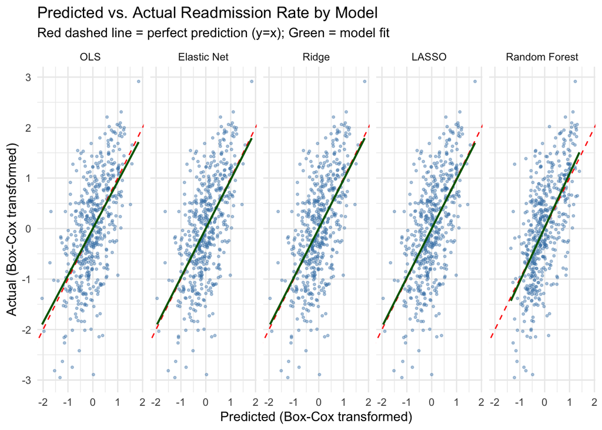

```r
## Build the plotting dataframe (must come before the ggplot)
plot_df <- bind_rows(
  data.frame(Model = "OLS",
             Predicted = as.vector(predict(bestMod, newdata = readyTest)),
             Actual    = as.vector(readyTest$bc_PredictedReadmissionRate)),
  data.frame(Model = "Elastic Net",
             Predicted = as.vector(predict(elasticMod, newdata = readyTest)),
             Actual    = as.vector(readyTest$bc_PredictedReadmissionRate)),
  data.frame(Model = "Ridge",
             Predicted = as.vector(ridge_pred),
             Actual    = as.vector(y_test)),
  data.frame(Model = "LASSO",
             Predicted = as.vector(lasso_pred),
             Actual    = as.vector(y_test)),
  data.frame(Model = "Random Forest",
             Predicted = as.vector(rf_pred),
             Actual    = as.vector(y_test))
)

## Reorder so Random Forest is last/highlighted
plot_df$Model <- factor(plot_df$Model,
                        levels = c("OLS", "Elastic Net", "Ridge", "LASSO", "Random Forest"))

ggplot(plot_df, aes(x = Predicted, y = Actual)) +
  geom_point(alpha = 0.4, color = "steelblue", size = 0.7) +
  geom_abline(intercept = 0, slope = 1, linetype = "dashed", color = "red") +
  geom_smooth(method = "lm", se = FALSE, color = "darkgreen", linewidth = 0.8) +
  facet_wrap(~ Model, nrow = 1) +    ## All in one row
  theme_minimal() +
  labs(title = "Predicted vs. Actual Readmission Rate by Model",
       subtitle = "Red dashed line = perfect prediction (y=x); Green = model fit",
       x = "Predicted (Box-Cox transformed)",
       y = "Actual (Box-Cox transformed)")
```

### 7.7 Final Conclusion:

Looking at Table 14, the three hypotheses from Q32 get pretty clear answers. Ridge, LASSO, and Elastic Net all landed at basically the same place as OLS — R² between 0.344 and 0.349, RMSE around 0.81. So regularization wasn’t the fix. LASSO only zeroed out one predictor (Postoperative.respiratory.failure.rate), and Ridge’s coefficient shrinking didn’t budge the test scores. Honestly, this isn’t that surprising — back in Section 6, when the Elastic Net’s tuning picked α = 0 and λ = 0, it was already telling us the linear models were doing their best.

Random Forest is the one that actually improved in this. Test R² = 0.40, RMSE = 0.776. The 43% OOB R² in training means it’s real improvement, not overfitting. And it makes sense — the OLS diagnostic plot had that little curve at the edges that linear models couldn’t capture, and that’s exactly what trees are good at.

The cool part is that all the models agree on what matters. Hospital.return.days.for.pneumonia.patients is the top predictor in OLS, Elastic Net, AND Random Forest. State, Medicare spending, and patient communication variables also show up consistently. Three very different algorithms pointing at the same features = that’s signal, not noise.

Random Forest is the strongest model I’ve got, but it’s not solving everything. Even at R² = 0.40, more than half the variation in readmissions is unexplained. That confirms what I suspected — hospital-level CMS data just can’t capture the patient-level stuff that really drives readmissions (comorbidities, social determinants, follow-up access). So rather than trying to predict exact readmission rates, I’d suggest using these models to identify which hospitals fall into the “needs intervention” bucket (using the variable importance and the k-means clusters together) and target resources that way. it may help us to understand more.

## Deliverables

I am looking for 1-2 markdown documents with their knitted HTML. For example, if you’re choosing Adventures 1 or 2, you may want to work through this document once, make a copy of this markdown document, move the source code to the **TOP**, edit the source code as needed, and then go through this again from the beginning using the new condition(s) you chose.

Alternatively, if you’re choosing Adventure 3, maybe you just choose to add on to the bottom of this document, replacing the ‘Choose Your Own Adventure’ section with your actual adventure.

Just make sure to answer the questions well,and make sure to justify the decisions you make. Tell me WHY you’re choosing the condition(s) you are in Adventures 1 or 2, or Tell me WHY you’re doing the analyses you are in Adventure 3. Other than that, make this your own learning adventure!

# References

Box, G. E. P., and D. R. Cox. 2018. “An Analysis of Transformations.” *Journal of the Royal Statistical Society: Series B (Methodological)* 26 (2): 211–43. https://doi.org/10.1111/j.2517-6161.1964.tb00553.x.

De Alba, Israel, and Alpesh Amin. 2014. “Pneumonia Readmissions: Risk Factors and Implications.” *Ochsner Journal* 14 (4): 649–54.

R Core Team. 2019. *R: A Language and Environment for Statistical Computing*. R Foundation for Statistical Computing. https://www.R-project.org.

Yeo, In‐Kwon, and Richard A. Johnson. 2000. “A New Family of Power Transformations to Improve Normality or Symmetry.” *Biometrika* 87 (4): 954–59. https://doi.org/10.1093/biomet/87.4.954.

Zou, Hui, and Trevor Hastie. 2005. “Regularization and Variable Selection via the Elastic Net.” *Journal of the Royal Statistical Society Series B: Statistical Methodology* 67 (2): 301–20. https://doi.org/10.1111/j.1467-9868.2005.00503.x.